# medicalbilling

```python
import math
import pandas as pd
import numpy as np
import seaborn as sns
import matplotlib.pyplot as plt

from sklearn.cluster import KMeans
from sklearn.preprocessing import scale
from sklearn.preprocessing import StandardScaler
from pyod.models.auto_encoder import AutoEncoder
from sklearn.model_selection import train_test_split
from pyod.models.combination import aom, moa, average, maximization
%autosave 180
%matplotlib inline
```

```
Autosaving every 180 seconds
```

## Table Of Content:

- Data Cleaning
- Feature Engineering
  - Feature 1
  - Feature 3
  - Feature 5
  - Feature 7
- Autoencoder Specification and Definition
  - Model 1
  - Model 2
  - Model 3
  - Aggregation
    - Average of average
    - Maximum of maximum
- IForest Specification and Definition
  - Model 1
  - Model 2
  - Model 3
  - Aggregation
    - Average of average
    - Maximum of maximum

# Data Cleaning

```python
data = pd.read_csv("/Users/aston/Desktop/CU2020Summer/M5/inpatientCharges.csv")
```

```python
#gets rid of the white space on both the left and right of each column
data.columns = data.columns.str.lstrip()
data.columns = data.columns.str.rstrip()
#changes the dtype of some columns into floats
data['Average Covered Charges']= data['Average Covered Charges'].replace('[\$,]', '', regex=True).astype(float)
data['Average Total Payments']= data['Average Total Payments'].replace('[\$,]', '', regex=True).astype(float)
data['Average Medicare Payments']= data['Average Medicare Payments'].replace('[\$,]', '', regex=True).astype(float)
```

```python
# see the number of unique values in each column
l1 = []
for col in data.columns:
    l1.append(data[col].unique().shape[0])
l2 = data.columns.tolist()
uniquedf = pd.DataFrame({'Column' : l2,
                        'UniqueCount' : l1 },
                        columns=['Column','UniqueCount'])
uniquedf.head() #decided to use Provider Id as the unique ID because it is the most granular
```

|  | Column | UniqueCount |
| --- | --- | --- |
| 0 | DRG Definition | 100 |
| 1 | Provider Id | 3337 |
| 2 | Provider Name | 3201 |
| 3 | Provider Street Address | 3326 |
| 4 | Provider City | 1977 |

# Feature Enginerring

```python
# calculate the amount of copy or 'out of pocket' cost to individual
data['Average Copay']= data['Average Total Payments'] - data['Average Medicare Payments']
```

```python
# The 'Total Payments' variable I created will consider anomalies in both Copay and Medicare payments.
data['Total Payments']= data['Total Discharges']*data['Average Total Payments']
```

```python
# The 'Medicare Coverage' variable also excludes the noise that comes from different hospital charge structures.
# It only considers the actual payment.
data['Medicare Coverage'] = data['Average Medicare Payments'] / data['Average Total Payments']
```

# F1 Average Total Payments Anomaly

### Calculate the "Precise Average Total Payments by DRG by State", use the simple standard deviation as the proxy, then encode a column whther an observation is outside of the 95% of the data sample, or 2 standard deviation away from the mean.

```python
data.sort_values(by=['DRG Definition']).head()
```

|  | DRG Definition | Provider Id | Provider Name | Provider Street Address | Provider City | Provider State | Provider Zip Code | Hospital Referral Region Description | Total Discharges | Average Covered Charges | Average Total Payments | Average Medicare Payments | Average Copay | Total Payments | Medicare Coverage |
| --- | --- | --- | --- | --- | --- | --- | --- | --- | --- | --- | --- | --- | --- | --- | --- |
| 0 | 039 - EXTRACRANIAL PROCEDURES W/O CC/MCC | 10001 | SOUTHEAST ALABAMA MEDICAL CENTER | 1108 ROSS CLARK CIRCLE | DOTHAN | AL | 36301 | AL - Dothan | 91 | 32963.07 | 5777.24 | 4763.73 | 1013.51 | 525728.84 | 0.824568 |
| 711 | 039 - EXTRACRANIAL PROCEDURES W/O CC/MCC | 340017 | MARGARET R PARDEE MEMORIAL HOSPITAL | 800 N JUSTICE ST | HENDERSONVILLE | NC | 28791 | NC - Asheville | 19 | 17132.63 | 5787.15 | 4959.78 | 827.37 | 109955.85 | 0.857033 |
| 712 | 039 - EXTRACRANIAL PROCEDURES W/O CC/MCC | 340027 | LENOIR MEMORIAL HOSPITAL | 100 AIRPORT RD | KINSTON | NC | 28501 | NC - Greenville | 22 | 19897.40 | 6421.45 | 4993.00 | 1428.45 | 141271.90 | 0.777550 |
| 713 | 039 - EXTRACRANIAL PROCEDURES W/O CC/MCC | 340028 | CAPE FEAR VALLEY MEDICAL CENTER | 1638 OWEN DRIVE P O BOX 2000 | FAYETTEVILLE | NC | 28302 | NC - Raleigh | 69 | 24250.44 | 7044.68 | 5907.13 | 1137.55 | 486082.92 | 0.838524 |
| 714 | 039 - EXTRACRANIAL PROCEDURES W/O CC/MCC | 340030 | DUKE UNIVERSITY HOSPITAL | PO BOX 3708 DUMC ERWIN RD | DURHAM | NC | 27710 | NC - Durham | 38 | 23353.18 | 8708.86 | 7849.18 | 859.68 | 330936.68 | 0.901287 |

```python
# mean total payment by state, by drg. Divide by the sum of the number of discharges. Yield average payment.
meanpaymentbenchmark = data.groupby(
    ["DRG Definition",'Provider State'])['Total Payments'].sum()/data.groupby(
    ["DRG Definition",'Provider State'])['Total Discharges'].sum()
meanpaymentbenchmark.head()
```

```
DRG Definition                            Provider State
039 - EXTRACRANIAL PROCEDURES W/O CC/MCC  AK                8401.950000
                                          AL                5857.170580
                                          AR                5932.607653
                                          AZ                7034.478416
                                          CA                8251.965364
dtype: float64
```

```python
# prep the benchmark dataframe before merge
meanpaymentbenchmark = pd.DataFrame(data = meanpaymentbenchmark)
meanpaymentbenchmark.reset_index(inplace=True)
meanpaymentbenchmark.rename(columns={0:'AverageTotal PaymentDRGState'},inplace=True)
meanpaymentbenchmark.head()
```

|  | DRG Definition | Provider State | AverageTotal PaymentDRGState |
| --- | --- | --- | --- |
| 0 | 039 - EXTRACRANIAL PROCEDURES W/O CC/MCC | AK | 8401.950000 |
| 1 | 039 - EXTRACRANIAL PROCEDURES W/O CC/MCC | AL | 5857.170580 |
| 2 | 039 - EXTRACRANIAL PROCEDURES W/O CC/MCC | AR | 5932.607653 |
| 3 | 039 - EXTRACRANIAL PROCEDURES W/O CC/MCC | AZ | 7034.478416 |
| 4 | 039 - EXTRACRANIAL PROCEDURES W/O CC/MCC | CA | 8251.965364 |

```python
# merge the calculated Average Total Payment with the simple calculated Average Payment
df2 = data.copy()
df2 = df2.groupby(['DRG Definition','Provider State'])['Average Total Payments'].describe()
df2['std'].fillna(value=0, inplace=True)
df2.isnull().values.any()
meanpaymentbenchmark = pd.merge(meanpaymentbenchmark, df2, on=['DRG Definition','Provider State'])
meanpaymentbenchmark.head()
```

|  | DRG Definition | Provider State | AverageTotal PaymentDRGState | count | mean | std | min | 25% | 50% | 75% | max |
| --- | --- | --- | --- | --- | --- | --- | --- | --- | --- | --- | --- |
| 0 | 039 - EXTRACRANIAL PROCEDURES W/O CC/MCC | AK | 8401.950000 | 1.0 | 8401.950000 | 0.000000 | 8401.95 | 8401.9500 | 8401.95 | 8401.9500 | 8401.95 |
| 1 | 039 - EXTRACRANIAL PROCEDURES W/O CC/MCC | AL | 5857.170580 | 23.0 | 5743.611739 | 628.702608 | 4968.00 | 5396.1050 | 5658.33 | 5882.4250 | 8031.12 |
| 2 | 039 - EXTRACRANIAL PROCEDURES W/O CC/MCC | AR | 5932.607653 | 16.0 | 6118.828750 | 1059.463235 | 5225.59 | 5558.5000 | 5890.00 | 6174.4650 | 9838.11 |
| 3 | 039 - EXTRACRANIAL PROCEDURES W/O CC/MCC | AZ | 7034.478416 | 24.0 | 7271.555833 | 1283.210551 | 5976.00 | 6452.8625 | 6959.89 | 7697.0975 | 11026.33 |
| 4 | 039 - EXTRACRANIAL PROCEDURES W/O CC/MCC | CA | 8251.965364 | 67.0 | 8387.932687 | 1807.867216 | 6390.25 | 7194.3500 | 7863.14 | 8811.2200 | 16744.82 |

Code on how to display groupby object df1 = data.groupby('Provider Id') df1 = df1.apply(lambda x: x).copy() type(df1)

```python
# merge the benchmark to the original data
df1 = pd.merge(data, meanpaymentbenchmark, on=['DRG Definition','Provider State'])
df1.drop(columns=['count', 'mean'], inplace=True)
df1.shape
```

```
(163065, 22)
```

```python
# merge the n for each DRG State
ndf = data.copy()
ndf = pd.DataFrame(data = ndf.groupby(['DRG Definition', 'Provider State'])['Total Discharges'].count())
ndf.rename(columns={'Total Discharges':'n'}, inplace=True)
df1 = pd.merge(df1, ndf, on=['DRG Definition','Provider State'])
df1.shape
```

```
(163065, 23)
```

```python
# define a function to encode any out of bound values
def confint(mean, std, n, data):
    hi = mean + 1.96*std
    lo = mean - 1.96*std
    if data > hi:
        return 1
    elif data < lo:
        return 1
    else:
        return 0
```

```python
# ensure the shape of two dataframes are the same
print(len(data))
print(len(df1))
```

```
163065
163065
```

```python
# run the outlier test, flag when the record is 2 std away from the mean
df1['Average TP Anomaly'] = df1.apply(lambda x:
          confint(x['AverageTotal PaymentDRGState'], x['std'], x['n'], x['Average Total Payments']),
          axis = 1)
data['Average TP Anomaly'] = df1['Average TP Anomaly']
df1.head(3)
```

|  | DRG Definition | Provider Id | Provider Name | Provider Street Address | Provider City | Provider State | Provider Zip Code | Hospital Referral Region Description | Total Discharges | Average Covered Charges | ... | Medicare Coverage | AverageTotal PaymentDRGState | std | min | 25% | 50% | 75% | max | n | Average TP Anomaly |
| --- | --- | --- | --- | --- | --- | --- | --- | --- | --- | --- | --- | --- | --- | --- | --- | --- | --- | --- | --- | --- | --- |
| 0 | 039 - EXTRACRANIAL PROCEDURES W/O CC/MCC | 10001 | SOUTHEAST ALABAMA MEDICAL CENTER | 1108 ROSS CLARK CIRCLE | DOTHAN | AL | 36301 | AL - Dothan | 91 | 32963.07 | ... | 0.824568 | 5857.17058 | 628.702608 | 4968.0 | 5396.105 | 5658.33 | 5882.425 | 8031.12 | 23 | 0 |
| 1 | 039 - EXTRACRANIAL PROCEDURES W/O CC/MCC | 10005 | MARSHALL MEDICAL CENTER SOUTH | 2505 U S HIGHWAY 431 NORTH | BOAZ | AL | 35957 | AL - Birmingham | 14 | 15131.85 | ... | 0.859896 | 5857.17058 | 628.702608 | 4968.0 | 5396.105 | 5658.33 | 5882.425 | 8031.12 | 23 | 0 |
| 2 | 039 - EXTRACRANIAL PROCEDURES W/O CC/MCC | 10006 | ELIZA COFFEE MEMORIAL HOSPITAL | 205 MARENGO STREET | FLORENCE | AL | 35631 | AL - Birmingham | 24 | 37560.37 | ... | 0.819472 | 5857.17058 | 628.702608 | 4968.0 | 5396.105 | 5658.33 | 5882.425 | 8031.12 | 23 | 0 |

3 rows × 24 columns

# F2 Average Total Payment Raio

### Average Total Payment Raio = "Average Total Payments" / "Precise Average Total Payments by DRG by State"

```python
df1['Average TP Ratio'] = df1['Average Total Payments'] / df1['AverageTotal PaymentDRGState']
data['Average TP Ratio'] = df1['Average TP Ratio']
data.head(3)
```

|  | DRG Definition | Provider Id | Provider Name | Provider Street Address | Provider City | Provider State | Provider Zip Code | Hospital Referral Region Description | Total Discharges | Average Covered Charges | Average Total Payments | Average Medicare Payments | Average Copay | Total Payments | Medicare Coverage | Average TP Anomaly | Average TP Ratio |
| --- | --- | --- | --- | --- | --- | --- | --- | --- | --- | --- | --- | --- | --- | --- | --- | --- | --- |
| 0 | 039 - EXTRACRANIAL PROCEDURES W/O CC/MCC | 10001 | SOUTHEAST ALABAMA MEDICAL CENTER | 1108 ROSS CLARK CIRCLE | DOTHAN | AL | 36301 | AL - Dothan | 91 | 32963.07 | 5777.24 | 4763.73 | 1013.51 | 525728.84 | 0.824568 | 0 | 0.986353 |
| 1 | 039 - EXTRACRANIAL PROCEDURES W/O CC/MCC | 10005 | MARSHALL MEDICAL CENTER SOUTH | 2505 U S HIGHWAY 431 NORTH | BOAZ | AL | 35957 | AL - Birmingham | 14 | 15131.85 | 5787.57 | 4976.71 | 810.86 | 81025.98 | 0.859896 | 0 | 0.988117 |
| 2 | 039 - EXTRACRANIAL PROCEDURES W/O CC/MCC | 10006 | ELIZA COFFEE MEMORIAL HOSPITAL | 205 MARENGO STREET | FLORENCE | AL | 35631 | AL - Birmingham | 24 | 37560.37 | 5434.95 | 4453.79 | 981.16 | 130438.80 | 0.819472 | 0 | 0.927914 |

# Feature 3 Average Total Discharge Anomaly

### Calculate the "Precise Average Total Discharges by DRG by State". Merge the benchmark to the original dataset, then encode a column whther an observation is outside of the 95% of the data sample, or 2 standard deviation away from the mean.

```python
# calculate the benchmark total charges by DRG by State
f2 = data.groupby(['DRG Definition', 'Provider State'])['Total Discharges'].describe()
f2.fillna(0, inplace=True)
f2 = pd.merge(data, f2, on=['DRG Definition', 'Provider State'])
f2.rename(columns={'mean':'benchmark'}, inplace=True)
```

```python
# flag when the record is 2 std away from the benchmark mean
f2['Average TD Anomaly'] = f2.apply(lambda x:
                                    confint(x['benchmark'],x['std'],x['count'],x['Total Discharges']),
                                    axis=1)
data['Average TD Anomaly'] = f2['Average TD Anomaly']
data.head(3)
```

|  | DRG Definition | Provider Id | Provider Name | Provider Street Address | Provider City | Provider State | Provider Zip Code | Hospital Referral Region Description | Total Discharges | Average Covered Charges | Average Total Payments | Average Medicare Payments | Average Copay | Total Payments | Medicare Coverage | Average TP Anomaly | Average TP Ratio | Average TD Anomaly |
| --- | --- | --- | --- | --- | --- | --- | --- | --- | --- | --- | --- | --- | --- | --- | --- | --- | --- | --- |
| 0 | 039 - EXTRACRANIAL PROCEDURES W/O CC/MCC | 10001 | SOUTHEAST ALABAMA MEDICAL CENTER | 1108 ROSS CLARK CIRCLE | DOTHAN | AL | 36301 | AL - Dothan | 91 | 32963.07 | 5777.24 | 4763.73 | 1013.51 | 525728.84 | 0.824568 | 0 | 0.986353 | 0 |
| 1 | 039 - EXTRACRANIAL PROCEDURES W/O CC/MCC | 10005 | MARSHALL MEDICAL CENTER SOUTH | 2505 U S HIGHWAY 431 NORTH | BOAZ | AL | 35957 | AL - Birmingham | 14 | 15131.85 | 5787.57 | 4976.71 | 810.86 | 81025.98 | 0.859896 | 0 | 0.988117 | 0 |
| 2 | 039 - EXTRACRANIAL PROCEDURES W/O CC/MCC | 10006 | ELIZA COFFEE MEMORIAL HOSPITAL | 205 MARENGO STREET | FLORENCE | AL | 35631 | AL - Birmingham | 24 | 37560.37 | 5434.95 | 4453.79 | 981.16 | 130438.80 | 0.819472 | 0 | 0.927914 | 0 |

## Example of confidence interval with total discharges

```python
data['Total Discharges']
```

```
0         91
1         14
2         24
3         25
4         18
          ..
163060    23
163061    11
163062    19
163063    11
163064    12
Name: Total Discharges, Length: 163065, dtype: int64
```

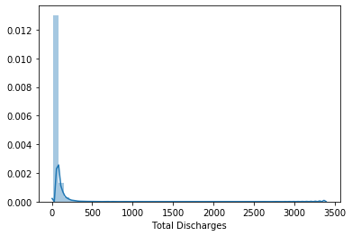

```python
sns.distplot(data['Total Discharges']);
```

```python
data['Total Discharges'].describe()
```

```
count    163065.000000
mean         42.776304
std          51.104042
min          11.000000
25%          17.000000
50%          27.000000
75%          49.000000
max        3383.000000
Name: Total Discharges, dtype: float64
```

```python
data1 = data.copy()
data1['mean'] = 42.776304
data1['std'] = 51.104
data1['n'] = 163065
```

```python
data1.apply(lambda x: confint(x['mean'], x['std'], x['n'], x['Total Discharges']), axis=1).sum()
```

```
5925
```

# F4 Average Total Discharge Ratio

### Average Total Discharge Ratio = "Total Discharge" / "Average Total Discharges by DRG by State"

```python
# calcualte a ratio as mentioned above
f2['Avearge TD Ratio'] = f2['Total Discharges'] / f2['benchmark']
```

```python
data['Average TD Ratio'] = f2['Avearge TD Ratio']
```

# F5 Medicare Coverage Ratio

### Medicare Coverage = Medicare Payment / Total Payment; Groupby DRG and Provider State to get the mean "Medicare Coverage". Compare each record's medicare coverage to the benchmark coverage.

```python
# calculate the medical coverage ratio
f5 = data.copy()
f5 = f5.groupby(['DRG Definition', 'Provider State'])['Medicare Coverage'].describe()['mean']
f5 = pd.merge(data, f5, on=['DRG Definition', 'Provider State'])
f5.rename(columns={'mean':'Medicare Coverage Ratio'}, inplace=True)
```

```python
# insert into the original dataframe
data.insert(15,column='Medicare Coverage Ratio', value=f5['Medicare Coverage Ratio'])
data.head(3)
```

|  | DRG Definition | Provider Id | Provider Name | Provider Street Address | Provider City | Provider State | Provider Zip Code | Hospital Referral Region Description | Total Discharges | Average Covered Charges | Average Total Payments | Average Medicare Payments | Average Copay | Total Payments | Medicare Coverage | Medicare Coverage Ratio | Average TP Anomaly | Average TP Ratio | Average TD Anomaly | Average TD Ratio |
| --- | --- | --- | --- | --- | --- | --- | --- | --- | --- | --- | --- | --- | --- | --- | --- | --- | --- | --- | --- | --- |
| 0 | 039 - EXTRACRANIAL PROCEDURES W/O CC/MCC | 10001 | SOUTHEAST ALABAMA MEDICAL CENTER | 1108 ROSS CLARK CIRCLE | DOTHAN | AL | 36301 | AL - Dothan | 91 | 32963.07 | 5777.24 | 4763.73 | 1013.51 | 525728.84 | 0.824568 | 0.801778 | 0 | 0.986353 | 0 | 2.381115 |
| 1 | 039 - EXTRACRANIAL PROCEDURES W/O CC/MCC | 10005 | MARSHALL MEDICAL CENTER SOUTH | 2505 U S HIGHWAY 431 NORTH | BOAZ | AL | 35957 | AL - Birmingham | 14 | 15131.85 | 5787.57 | 4976.71 | 810.86 | 81025.98 | 0.859896 | 0.801778 | 0 | 0.988117 | 0 | 0.366325 |
| 2 | 039 - EXTRACRANIAL PROCEDURES W/O CC/MCC | 10006 | ELIZA COFFEE MEMORIAL HOSPITAL | 205 MARENGO STREET | FLORENCE | AL | 35631 | AL - Birmingham | 24 | 37560.37 | 5434.95 | 4453.79 | 981.16 | 130438.80 | 0.819472 | 0.801778 | 0 | 0.927914 | 0 | 0.627986 |

# F6 Average Covered Charges Anomaly

### Average Covered Charges +- 2 Standard deviation from Benchmark of Average Covered Charges

```python
# create the 'count', 'mean', 'std' for the benchmark
f6 = data.copy()
f6 = f6.groupby(['DRG Definition', 'Provider State'])['Average Covered Charges'].describe()[['count', 'mean', 'std']]
f6.head(3)
```

| DRG Definition | Provider State | count | mean | std |
| --- | --- | --- | --- | --- |
| 039 - EXTRACRANIAL PROCEDURES W/O CC/MCC | AK | 1.0 | 34805.130000 | NaN |
|  | AL | 23.0 | 32044.436957 | 20153.076462 |
|  | AR | 16.0 | 27463.263125 | 20282.962492 |

```python
# fill the NaN values in STD with 0, because only one observation
f6['std'].fillna(value=0, inplace=True)
f6.reset_index(inplace=True)
f6.head(3)
```

|  | DRG Definition | Provider State | count | mean | std |
| --- | --- | --- | --- | --- | --- |
| 0 | 039 - EXTRACRANIAL PROCEDURES W/O CC/MCC | AK | 1.0 | 34805.130000 | 0.000000 |
| 1 | 039 - EXTRACRANIAL PROCEDURES W/O CC/MCC | AL | 23.0 | 32044.436957 | 20153.076462 |
| 2 | 039 - EXTRACRANIAL PROCEDURES W/O CC/MCC | AR | 16.0 | 27463.263125 | 20282.962492 |

```python
# merge the benchmark statistics to the original dataframe
f6 = pd.merge(data, f6, on=['DRG Definition', 'Provider State'])
f6.rename(columns={'mean':'Average Covered Charges BenchMean',
                   'count':'Average Covered Charges BenchCount',
                   'std':'Average Covered Charges BenchStd'}, inplace=True)
f6.head(3)
```

|  | DRG Definition | Provider Id | Provider Name | Provider Street Address | Provider City | Provider State | Provider Zip Code | Hospital Referral Region Description | Total Discharges | Average Covered Charges | ... | Total Payments | Medicare Coverage | Medicare Coverage Ratio | Average TP Anomaly | Average TP Ratio | Average TD Anomaly | Average TD Ratio | Average Covered Charges BenchCount | Average Covered Charges BenchMean | Average Covered Charges BenchStd |
| --- | --- | --- | --- | --- | --- | --- | --- | --- | --- | --- | --- | --- | --- | --- | --- | --- | --- | --- | --- | --- | --- |
| 0 | 039 - EXTRACRANIAL PROCEDURES W/O CC/MCC | 10001 | SOUTHEAST ALABAMA MEDICAL CENTER | 1108 ROSS CLARK CIRCLE | DOTHAN | AL | 36301 | AL - Dothan | 91 | 32963.07 | ... | 525728.84 | 0.824568 | 0.801778 | 0 | 0.986353 | 0 | 2.381115 | 23.0 | 32044.436957 | 20153.076462 |
| 1 | 039 - EXTRACRANIAL PROCEDURES W/O CC/MCC | 10005 | MARSHALL MEDICAL CENTER SOUTH | 2505 U S HIGHWAY 431 NORTH | BOAZ | AL | 35957 | AL - Birmingham | 14 | 15131.85 | ... | 81025.98 | 0.859896 | 0.801778 | 0 | 0.988117 | 0 | 0.366325 | 23.0 | 32044.436957 | 20153.076462 |
| 2 | 039 - EXTRACRANIAL PROCEDURES W/O CC/MCC | 10006 | ELIZA COFFEE MEMORIAL HOSPITAL | 205 MARENGO STREET | FLORENCE | AL | 35631 | AL - Birmingham | 24 | 37560.37 | ... | 130438.80 | 0.819472 | 0.801778 | 0 | 0.927914 | 0 | 0.627986 | 23.0 | 32044.436957 | 20153.076462 |

3 rows × 23 columns

```python
# apply the +- 2 standard deviation function to the dataframe
f6['Average Covered Charges Anomaly'] = f6.apply(lambda row: confint(row['Average Covered Charges BenchMean'],
                                                                     row['Average Covered Charges BenchStd'],
                                                                     row['Average Covered Charges BenchCount'],
                                                                     row['Average Covered Charges']), axis=1)
```

```python
# append the calculated anomaly score back to the original dataframe
data['Average Covered Charges Anomaly'] = f6['Average Covered Charges Anomaly']
data.head(3)
```

|  | DRG Definition | Provider Id | Provider Name | Provider Street Address | Provider City | Provider State | Provider Zip Code | Hospital Referral Region Description | Total Discharges | Average Covered Charges | ... | Average Medicare Payments | Average Copay | Total Payments | Medicare Coverage | Medicare Coverage Ratio | Average TP Anomaly | Average TP Ratio | Average TD Anomaly | Average TD Ratio | Average Covered Charges Anomaly |
| --- | --- | --- | --- | --- | --- | --- | --- | --- | --- | --- | --- | --- | --- | --- | --- | --- | --- | --- | --- | --- | --- |
| 0 | 039 - EXTRACRANIAL PROCEDURES W/O CC/MCC | 10001 | SOUTHEAST ALABAMA MEDICAL CENTER | 1108 ROSS CLARK CIRCLE | DOTHAN | AL | 36301 | AL - Dothan | 91 | 32963.07 | ... | 4763.73 | 1013.51 | 525728.84 | 0.824568 | 0.801778 | 0 | 0.986353 | 0 | 2.381115 | 0 |
| 1 | 039 - EXTRACRANIAL PROCEDURES W/O CC/MCC | 10005 | MARSHALL MEDICAL CENTER SOUTH | 2505 U S HIGHWAY 431 NORTH | BOAZ | AL | 35957 | AL - Birmingham | 14 | 15131.85 | ... | 4976.71 | 810.86 | 81025.98 | 0.859896 | 0.801778 | 0 | 0.988117 | 0 | 0.366325 | 0 |
| 2 | 039 - EXTRACRANIAL PROCEDURES W/O CC/MCC | 10006 | ELIZA COFFEE MEMORIAL HOSPITAL | 205 MARENGO STREET | FLORENCE | AL | 35631 | AL - Birmingham | 24 | 37560.37 | ... | 4453.79 | 981.16 | 130438.80 | 0.819472 | 0.801778 | 0 | 0.927914 | 0 | 0.627986 | 0 |

3 rows × 21 columns

# F7 Average Covered Charges Ratio

### Average Covered Charges Ratio=Average Covered Charges/Average Covered Charges Benchmark

```python
# calculate the ratio
f6['Average Covered Charges Ratio'] = f6['Average Covered Charges']/f6['Average Covered Charges BenchMean']
```

```python
# append the ratio back to the original dataframe
data['Average Covered Charges Ratio'] = f6['Average Covered Charges Ratio']
data.head(3)
```

|  | DRG Definition | Provider Id | Provider Name | Provider Street Address | Provider City | Provider State | Provider Zip Code | Hospital Referral Region Description | Total Discharges | Average Covered Charges | ... | Average Copay | Total Payments | Medicare Coverage | Medicare Coverage Ratio | Average TP Anomaly | Average TP Ratio | Average TD Anomaly | Average TD Ratio | Average Covered Charges Anomaly | Average Covered Charges Ratio |
| --- | --- | --- | --- | --- | --- | --- | --- | --- | --- | --- | --- | --- | --- | --- | --- | --- | --- | --- | --- | --- | --- |
| 0 | 039 - EXTRACRANIAL PROCEDURES W/O CC/MCC | 10001 | SOUTHEAST ALABAMA MEDICAL CENTER | 1108 ROSS CLARK CIRCLE | DOTHAN | AL | 36301 | AL - Dothan | 91 | 32963.07 | ... | 1013.51 | 525728.84 | 0.824568 | 0.801778 | 0 | 0.986353 | 0 | 2.381115 | 0 | 1.028667 |
| 1 | 039 - EXTRACRANIAL PROCEDURES W/O CC/MCC | 10005 | MARSHALL MEDICAL CENTER SOUTH | 2505 U S HIGHWAY 431 NORTH | BOAZ | AL | 35957 | AL - Birmingham | 14 | 15131.85 | ... | 810.86 | 81025.98 | 0.859896 | 0.801778 | 0 | 0.988117 | 0 | 0.366325 | 0 | 0.472215 |
| 2 | 039 - EXTRACRANIAL PROCEDURES W/O CC/MCC | 10006 | ELIZA COFFEE MEMORIAL HOSPITAL | 205 MARENGO STREET | FLORENCE | AL | 35631 | AL - Birmingham | 24 | 37560.37 | ... | 981.16 | 130438.80 | 0.819472 | 0.801778 | 0 | 0.927914 | 0 | 0.627986 | 0 | 1.172134 |

3 rows × 22 columns

# Autoencoder

- Theory: The backbone of Autoencoder is deep learning. It functions kind of like Recurrent Neural Network, but Autoencoder is a special type of neural network. The middle layer of the model has fewer nodes than the begginning or the end. As the information moves from the outter layers into the inner layers, only important information is being kept. After the image has been reassembled in the outerlayer, the information moves into the beginning layer and start the looop again. During the process of dimensional reduction, outliers are the byproduct of this neural network.
- Tran/test split ratio: 60:40
- clf1 has hidden_neurons = [25, 2, 2, 25]
- clf2 has hidden_neurons = [25, 10, 2, 10, 25]
- clf3 has hidden_neurons = [25, 15, 10, 2, 10, 15, 25])
- The number of the hidden layers and the number of neutrons in a hidden layer: if there are too many hidden layers or too many neutrons, the model tends to overfit; otherwise the model tends to underfit.

### Model 1

```python
df = data.drop(columns=['DRG Definition', 'Provider Id', 'Provider Name',
       'Provider Street Address', 'Provider City', 'Provider State',
       'Provider Zip Code', 'Hospital Referral Region Description',
       'Total Discharges', 'Average Covered Charges', 'Average Total Payments',
       'Average Medicare Payments']).copy()
df.head()
```

|  | Average Copay | Total Payments | Medicare Coverage | Medicare Coverage Ratio | Average TP Anomaly | Average TP Ratio | Average TD Anomaly | Average TD Ratio | Average Covered Charges Anomaly | Average Covered Charges Ratio |
| --- | --- | --- | --- | --- | --- | --- | --- | --- | --- | --- |
| 0 | 1013.51 | 525728.84 | 0.824568 | 0.801778 | 0 | 0.986353 | 0 | 2.381115 | 0 | 1.028667 |
| 1 | 810.86 | 81025.98 | 0.859896 | 0.801778 | 0 | 0.988117 | 0 | 0.366325 | 0 | 0.472215 |
| 2 | 981.16 | 130438.80 | 0.819472 | 0.801778 | 0 | 0.927914 | 0 | 0.627986 | 0 | 1.172134 |
| 3 | 1288.40 | 135439.00 | 0.762181 | 0.801778 | 0 | 0.924945 | 0 | 0.654152 | 0 | 0.436840 |
| 4 | 806.89 | 101849.94 | 0.857398 | 0.801778 | 0 | 0.966052 | 0 | 0.470990 | 0 | 0.987169 |

```python
# split the data
X_train, X_test = train_test_split(
    df, test_size=0.40, random_state=42)
```

```python
len(X_train)/ len(X_test)
```

```
1.5
```

```python
# standardize the predictors
X_train1 = X_train.copy()
X_test1 = X_test.copy()
X_train = StandardScaler().fit_transform(X_train)
X_train = pd.DataFrame(X_train)
X_test = StandardScaler().fit_transform(X_test)
X_test = pd.DataFrame(X_test)
```

```python
# run the model
clf1 = AutoEncoder(hidden_neurons =[25, 2, 2, 25])
clf1.fit(X_train)
```

```
Model: "sequential"
_________________________________________________________________
Layer (type)                 Output Shape              Param #
=================================================================
dense (Dense)                (None, 10)                110
_________________________________________________________________
dropout (Dropout)            (None, 10)                0
_________________________________________________________________
dense_1 (Dense)              (None, 10)                110
_________________________________________________________________
dropout_1 (Dropout)          (None, 10)                0
_________________________________________________________________
dense_2 (Dense)              (None, 25)                275
_________________________________________________________________
dropout_2 (Dropout)          (None, 25)                0
_________________________________________________________________
dense_3 (Dense)              (None, 2)                 52
_________________________________________________________________
dropout_3 (Dropout)          (None, 2)                 0
_________________________________________________________________
dense_4 (Dense)              (None, 2)                 6
_________________________________________________________________
dropout_4 (Dropout)          (None, 2)                 0
_________________________________________________________________
dense_5 (Dense)              (None, 25)                75
_________________________________________________________________
dropout_5 (Dropout)          (None, 25)                0
_________________________________________________________________
dense_6 (Dense)              (None, 10)                260
=================================================================
Total params: 888
Trainable params: 888
Non-trainable params: 0
_________________________________________________________________
None
```

```
AutoEncoder(batch_size=32, contamination=0.1, dropout_rate=0.2, epochs=100,
      hidden_activation='relu', hidden_neurons=[25, 2, 2, 25],
      l2_regularizer=0.1,
      loss=<function mean_squared_error at 0x7f8e24102dd0>,
      optimizer='adam', output_activation='sigmoid', preprocessing=True,
      random_state=None, validation_size=0.1, verbose=1)
```

```python
# get the anomaly score for X_train for the first clf1
y_train_scores = clf1.decision_scores_
```

```python
# fit the model on the test data
y_test_pred = clf1.predict(X_test)  # outlier labels (0 or 1)

# get the anomaly score for X_test for the first clf1
y_test_scores = clf1.decision_function(X_test)  # outlier scores

y_test_pred = pd.Series(y_test_pred)
y_test_scores = pd.Series(y_test_scores)
```

```python
# see the results
y_test_pred.value_counts()
```

```
0    58573
1     6653
dtype: int64
```

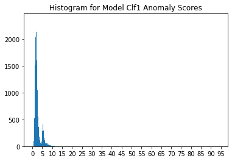

```python
plt.hist(y_test_scores, bins='auto')  # arguments are passed to np.histogram
plt.title("Histogram for Model Clf1 Anomaly Scores")
plt.xticks(ticks=range(0,100,5))
plt.show()
```

### I see that 10 is a good cut off score, as there are so many outliers sporadically laying between the range of 10 to 100 (they are just less freqent, you may not see them). The cut off point at 3 may seem tempting, but the entire count will be 10% of the population had I chosen 3 as the cutoff score.

```python
df_test = X_test1.copy()
df_test.reset_index(inplace=True)
df_test.head()
```

|  | index | Average Copay | Total Payments | Medicare Coverage | Medicare Coverage Ratio | Average TP Anomaly | Average TP Ratio | Average TD Anomaly | Average TD Ratio | Average Covered Charges Anomaly | Average Covered Charges Ratio |
| --- | --- | --- | --- | --- | --- | --- | --- | --- | --- | --- | --- |
| 0 | 136351 | 1178.91 | 1267173.88 | 0.847423 | 0.893927 | 0 | 0.861660 | 1 | 3.910825 | 0 | 0.666902 |
| 1 | 89009 | 1035.00 | 206723.92 | 0.934913 | 0.884543 | 0 | 0.822939 | 0 | 1.150533 | 0 | 0.941099 |
| 2 | 123343 | 777.85 | 48455.94 | 0.791315 | 0.702449 | 0 | 0.792511 | 0 | 0.623955 | 0 | 0.632328 |
| 3 | 24542 | 955.57 | 245979.80 | 0.829071 | 0.890251 | 0 | 1.176378 | 0 | 1.069212 | 0 | 1.092113 |
| 4 | 65814 | 777.54 | 156640.90 | 0.870940 | 0.855992 | 0 | 0.915006 | 0 | 2.016124 | 1 | 2.267758 |

```python
df_test['score'] = y_test_scores
df_test['cluster'] = np.where(df_test['score']<10, 0, 1)
df_test['cluster'].value_counts()
```

```
0    64941
1      285
Name: cluster, dtype: int64
```

```python
summary1 = df_test.groupby('cluster').mean()
summary1.insert(0,column='count',value=df_test['cluster'].value_counts())
summary1.drop(columns='index', inplace=True)
summary1
```

| cluster | count | Average Copay | Total Payments | Medicare Coverage | Medicare Coverage Ratio | Average TP Anomaly | Average TP Ratio | Average TD Anomaly | Average TD Ratio | Average Covered Charges Anomaly | Average Covered Charges Ratio | score |
| --- | --- | --- | --- | --- | --- | --- | --- | --- | --- | --- | --- | --- |
| 0 | 64941 | 1186.224718 | 3.955748e+05 | 0.847117 | 0.846452 | 0.046042 | 0.987551 | 0.050615 | 0.997692 | 0.042285 | 0.996912 | 2.561792 |
| 1 | 285 | 7578.911719 | 3.515197e+06 | 0.728384 | 0.869805 | 0.333333 | 1.412740 | 0.178947 | 1.642855 | 0.312281 | 1.625968 | 13.881528 |

## Model 2

```python
clf2 = AutoEncoder(hidden_neurons =[25, 10, 2, 10, 25])
clf2.fit(X_train)

# clf.decision_function: Predict raw anomaly score of X using the fitted detector.
y_test_scores = clf2.decision_function(X_test)  # outlier scores
y_test_scores = pd.Series(y_test_scores)
```

```
Model: "sequential_1"
_________________________________________________________________
Layer (type)                 Output Shape              Param #
=================================================================
dense_7 (Dense)              (None, 10)                110
_________________________________________________________________
dropout_6 (Dropout)          (None, 10)                0
_________________________________________________________________
dense_8 (Dense)              (None, 10)                110
_________________________________________________________________
dropout_7 (Dropout)          (None, 10)                0
_________________________________________________________________
dense_9 (Dense)              (None, 25)                275
_________________________________________________________________
dropout_8 (Dropout)          (None, 25)                0
_________________________________________________________________
dense_10 (Dense)             (None, 10)                260
_________________________________________________________________
dropout_9 (Dropout)          (None, 10)                0
_________________________________________________________________
dense_11 (Dense)             (None, 2)                 22
_________________________________________________________________
dropout_10 (Dropout)         (None, 2)                 0
_________________________________________________________________
dense_12 (Dense)             (None, 10)                30
_________________________________________________________________
dropout_11 (Dropout)         (None, 10)                0
_________________________________________________________________
dense_13 (Dense)             (None, 25)                275
_________________________________________________________________
dropout_12 (Dropout)         (None, 25)                0
_________________________________________________________________
dense_14 (Dense)             (None, 10)                260
=================================================================
Total params: 1,342
Trainable params: 1,342
Non-trainable params: 0
_________________________________________________________________
None
```

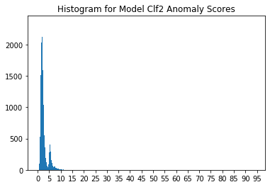

```python
plt.hist(y_test_scores, bins='auto')  # arguments are passed to np.histogram
plt.title("Histogram for Model Clf2 Anomaly Scores")
plt.xticks(ticks=range(0,100,5))
plt.show()
```

```python
df_test = X_test1.copy()
df_test.reset_index(inplace=True)
df_test.head()
```

|  | index | Average Copay | Total Payments | Medicare Coverage | Medicare Coverage Ratio | Average TP Anomaly | Average TP Ratio | Average TD Anomaly | Average TD Ratio | Average Covered Charges Anomaly | Average Covered Charges Ratio |
| --- | --- | --- | --- | --- | --- | --- | --- | --- | --- | --- | --- |
| 0 | 136351 | 1178.91 | 1267173.88 | 0.847423 | 0.893927 | 0 | 0.861660 | 1 | 3.910825 | 0 | 0.666902 |
| 1 | 89009 | 1035.00 | 206723.92 | 0.934913 | 0.884543 | 0 | 0.822939 | 0 | 1.150533 | 0 | 0.941099 |
| 2 | 123343 | 777.85 | 48455.94 | 0.791315 | 0.702449 | 0 | 0.792511 | 0 | 0.623955 | 0 | 0.632328 |
| 3 | 24542 | 955.57 | 245979.80 | 0.829071 | 0.890251 | 0 | 1.176378 | 0 | 1.069212 | 0 | 1.092113 |
| 4 | 65814 | 777.54 | 156640.90 | 0.870940 | 0.855992 | 0 | 0.915006 | 0 | 2.016124 | 1 | 2.267758 |

```python
df_test['score'] = y_test_scores
df_test['cluster'] = np.where(df_test['score']<10, 0, 1)
df_test['cluster'].value_counts()
```

```
0    64941
1      285
Name: cluster, dtype: int64
```

```python
summary2 = df_test.groupby('cluster').mean()
summary2.insert(0,column='count',value=df_test['cluster'].value_counts())
summary2.drop(columns='index', inplace=True)
summary2
```

| cluster | count | Average Copay | Total Payments | Medicare Coverage | Medicare Coverage Ratio | Average TP Anomaly | Average TP Ratio | Average TD Anomaly | Average TD Ratio | Average Covered Charges Anomaly | Average Covered Charges Ratio | score |
| --- | --- | --- | --- | --- | --- | --- | --- | --- | --- | --- | --- | --- |
| 0 | 64941 | 1186.224718 | 3.955748e+05 | 0.847117 | 0.846452 | 0.046042 | 0.987551 | 0.050615 | 0.997692 | 0.042285 | 0.996912 | 2.561888 |
| 1 | 285 | 7578.911719 | 3.515197e+06 | 0.728384 | 0.869805 | 0.333333 | 1.412740 | 0.178947 | 1.642855 | 0.312281 | 1.625968 | 13.881263 |

## Discussion:

- The results are very similar to those in Model 1. I will display all three models at the end of model three. Again, all the numbers for Cluster 1 here are significantly different than those for Cluster 0. The Average Copay, Average Total Payment Anomaly, Average Total Discharge Anomaly, and Average Covered Charges Anomaly and their respective ratios are different for each of the two clusters. It is apparently that Cluster 1 is different than that of Cluster 0.

## Model 3

```python
clf3 = AutoEncoder(hidden_neurons =[25, 15, 10, 2, 10,15, 25])
clf3.fit(X_train)

# clf.decision_function: Predict raw anomaly score of X using the fitted detector.
y_test_scores = clf3.decision_function(X_test)  # outlier scores
y_test_scores = pd.Series(y_test_scores)
```

```
Model: "sequential_2"
_________________________________________________________________
Layer (type)                 Output Shape              Param #
=================================================================
dense_15 (Dense)             (None, 10)                110
_________________________________________________________________
dropout_13 (Dropout)         (None, 10)                0
_________________________________________________________________
dense_16 (Dense)             (None, 10)                110
_________________________________________________________________
dropout_14 (Dropout)         (None, 10)                0
_________________________________________________________________
dense_17 (Dense)             (None, 25)                275
_________________________________________________________________
dropout_15 (Dropout)         (None, 25)                0
_________________________________________________________________
dense_18 (Dense)             (None, 15)                390
_________________________________________________________________
dropout_16 (Dropout)         (None, 15)                0
_________________________________________________________________
dense_19 (Dense)             (None, 10)                160
_________________________________________________________________
dropout_17 (Dropout)         (None, 10)                0
_________________________________________________________________
dense_20 (Dense)             (None, 2)                 22
_________________________________________________________________
dropout_18 (Dropout)         (None, 2)                 0
_________________________________________________________________
dense_21 (Dense)             (None, 10)                30
_________________________________________________________________
dropout_19 (Dropout)         (None, 10)                0
_________________________________________________________________
dense_22 (Dense)             (None, 15)                165
_________________________________________________________________
dropout_20 (Dropout)         (None, 15)                0
_________________________________________________________________
dense_23 (Dense)             (None, 25)                400
_________________________________________________________________
dropout_21 (Dropout)         (None, 25)                0
_________________________________________________________________
dense_24 (Dense)             (None, 10)                260
=================================================================
Total params: 1,922
Trainable params: 1,922
Non-trainable params: 0
_________________________________________________________________
None
```

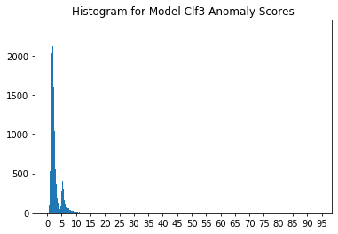

```python
plt.hist(y_test_scores, bins='auto')  # arguments are passed to np.histogram
plt.title("Histogram for Model Clf3 Anomaly Scores")
plt.xticks(ticks=range(0,100,5))
plt.show()
```

```python
df_test = X_test1.copy()
df_test.reset_index(inplace=True)
df_test.head()
```

|  | index | Average Copay | Total Payments | Medicare Coverage | Medicare Coverage Ratio | Average TP Anomaly | Average TP Ratio | Average TD Anomaly | Average TD Ratio | Average Covered Charges Anomaly | Average Covered Charges Ratio |
| --- | --- | --- | --- | --- | --- | --- | --- | --- | --- | --- | --- |
| 0 | 136351 | 1178.91 | 1267173.88 | 0.847423 | 0.893927 | 0 | 0.861660 | 1 | 3.910825 | 0 | 0.666902 |
| 1 | 89009 | 1035.00 | 206723.92 | 0.934913 | 0.884543 | 0 | 0.822939 | 0 | 1.150533 | 0 | 0.941099 |
| 2 | 123343 | 777.85 | 48455.94 | 0.791315 | 0.702449 | 0 | 0.792511 | 0 | 0.623955 | 0 | 0.632328 |
| 3 | 24542 | 955.57 | 245979.80 | 0.829071 | 0.890251 | 0 | 1.176378 | 0 | 1.069212 | 0 | 1.092113 |
| 4 | 65814 | 777.54 | 156640.90 | 0.870940 | 0.855992 | 0 | 0.915006 | 0 | 2.016124 | 1 | 2.267758 |

```python
df_test['score'] = y_test_scores
df_test['cluster'] = np.where(df_test['score']<10, 0, 1)
df_test['cluster'].value_counts()
```

```
0    64941
1      285
Name: cluster, dtype: int64
```

```python
summary3 = df_test.groupby('cluster').mean()
summary3.insert(0,column='count',value=df_test['cluster'].value_counts())
summary3.drop(columns='index', inplace=True)
summary3
```

| cluster | count | Average Copay | Total Payments | Medicare Coverage | Medicare Coverage Ratio | Average TP Anomaly | Average TP Ratio | Average TD Anomaly | Average TD Ratio | Average Covered Charges Anomaly | Average Covered Charges Ratio | score |
| --- | --- | --- | --- | --- | --- | --- | --- | --- | --- | --- | --- | --- |
| 0 | 64941 | 1186.224718 | 3.955748e+05 | 0.847117 | 0.846452 | 0.046042 | 0.987551 | 0.050615 | 0.997692 | 0.042285 | 0.996912 | 2.561848 |
| 1 | 285 | 7578.911719 | 3.515197e+06 | 0.728384 | 0.869805 | 0.333333 | 1.412740 | 0.178947 | 1.642855 | 0.312281 | 1.625968 | 13.881596 |

## Discussion:

- The results are very similar to those in Model 1 and Model 2, even the count for Cluster 1 is the same as Cluster 1 in Model 1 and Model 2. I will display all three models at the end of model three. Again, all the numbers for Cluster 1 here are significantly different than those for Cluster 0. The Average Copay, Average Total Payment Anomaly, Average Total Discharge Anomaly, and Average Covered Charges Anomaly and their respective ratios are different for each of the two clusters. It is apparently that Cluster 1 is different than that of Cluster 0.

```python
summary2
```

| cluster | count | Average Copay | Total Payments | Medicare Coverage | Medicare Coverage Ratio | Average TP Anomaly | Average TP Ratio | Average TD Anomaly | Average TD Ratio | Average Covered Charges Anomaly | Average Covered Charges Ratio | score |
| --- | --- | --- | --- | --- | --- | --- | --- | --- | --- | --- | --- | --- |
| 0 | 64941 | 1186.224718 | 3.955748e+05 | 0.847117 | 0.846452 | 0.046042 | 0.987551 | 0.050615 | 0.997692 | 0.042285 | 0.996912 | 2.561888 |
| 1 | 285 | 7578.911719 | 3.515197e+06 | 0.728384 | 0.869805 | 0.333333 | 1.412740 | 0.178947 | 1.642855 | 0.312281 | 1.625968 | 13.881263 |

## Discussion:

```python
summary1
```

| cluster | count | Average Copay | Total Payments | Medicare Coverage | Medicare Coverage Ratio | Average TP Anomaly | Average TP Ratio | Average TD Anomaly | Average TD Ratio | Average Covered Charges Anomaly | Average Covered Charges Ratio | score |
| --- | --- | --- | --- | --- | --- | --- | --- | --- | --- | --- | --- | --- |
| 0 | 64941 | 1186.224718 | 3.955748e+05 | 0.847117 | 0.846452 | 0.046042 | 0.987551 | 0.050615 | 0.997692 | 0.042285 | 0.996912 | 2.561792 |
| 1 | 285 | 7578.911719 | 3.515197e+06 | 0.728384 | 0.869805 | 0.333333 | 1.412740 | 0.178947 | 1.642855 | 0.312281 | 1.625968 | 13.881528 |

## Discussion:

# Aggregated Models

```python
# put all the predictions in a data frame
train_scores = pd.DataFrame({'clf1': clf1.decision_scores_,
                             'clf2': clf2.decision_scores_,
                             'clf3': clf3.decision_scores_
                            })

test_scores  = pd.DataFrame({'clf1': clf1.decision_function(X_test),
                             'clf2': clf2.decision_function(X_test),
                             'clf3': clf3.decision_function(X_test)
                            })
```

```python
train_scores.head()
```

|  | clf1 | clf2 | clf3 |
| --- | --- | --- | --- |
| 0 | 1.883875 | 1.884123 | 1.883690 |
| 1 | 2.376199 | 2.376267 | 2.376446 |
| 2 | 8.145976 | 8.145678 | 8.145933 |
| 3 | 2.126117 | 2.125867 | 2.126125 |
| 4 | 2.522700 | 2.522659 | 2.522578 |

```python
test_scores.head()
```

|  | clf1 | clf2 | clf3 |
| --- | --- | --- | --- |
| 0 | 6.342776 | 6.342521 | 6.342215 |
| 1 | 1.570524 | 1.570650 | 1.570318 |
| 2 | 2.956536 | 2.956737 | 2.956607 |
| 3 | 1.342036 | 1.342244 | 1.342330 |
| 4 | 6.005816 | 6.005267 | 6.006013 |

```python
# Although we did standardization before, it was for the variables.
# Now we do the standardization for the decision scores
train_scores_norm = StandardScaler().fit_transform(train_scores)
test_scores_norm = StandardScaler().fit_transform(test_scores)
```

```python
train_scores_norm.shape
```

```
(97839, 3)
```

## Average of average

```python
# Combination by average
y_by_average = average(test_scores_norm)
y_by_average[1:10]
```

```
array([-0.58355417,  0.19361434, -0.71155316,  1.90315409, -0.42379063,
       -0.11316539, -0.65854296,  1.77711667, -0.36440529])
```

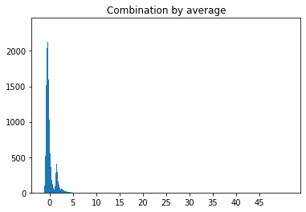

```python
# Combination by average
y_by_average = average(test_scores_norm)

plt.hist(y_by_average, bins='auto')  # arguments are passed to np.histogram
plt.title("Combination by average")
plt.xticks(ticks=range(0,50,5))
plt.show()
```

## Discussion:

After standardization, the anomaly scores clustered around 0. Then I will find a new cutoff point. Here I think 5 is a reasonable one.

```python
df_test = pd.DataFrame(X_test)
df_test['y_by_average_score'] = y_by_average
df_test['y_by_average_cluster'] = np.where(df_test['y_by_average_score']<5, 0, 1)
df_test['y_by_average_cluster'].value_counts()
```

```
0    65079
1      147
Name: y_by_average_cluster, dtype: int64
```

```python
# describe the outliers
df_test.groupby('y_by_average_cluster').mean()
```

| y_by_average_cluster | 0 | 1 | 2 | 3 | 4 | 5 | 6 | 7 | 8 | 9 | y_by_average_score |
| --- | --- | --- | --- | --- | --- | --- | --- | --- | --- | --- | --- |
| 0 | -0.017683 | -0.014418 | 0.004028 | -0.001085 | -0.002392 | -0.004929 | -0.000940 | -0.001992 | -0.001855 | -0.002478 | -0.018097 |
| 1 | 7.828313 | 6.383119 | -1.783217 | 0.480264 | 1.059066 | 2.182271 | 0.416059 | 0.881955 | 0.821090 | 1.097258 | 8.012004 |

## Discussion:

After standardization, Cluster 1 has 147 number of outliers, which is a lot fewer than 285 in either of model 1, model 2, and model 3. I think the model aggregation shows its benefits here. Because I chose a similar cutoff point in the histogram for the aggreagation model, I don't think I have contributed to a decrease in the number of observations in cluster 1. I think that the hsitogram can better detect those outliers by following "the average of the average" methodology.

### Maximum of maximum

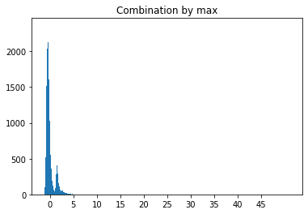

```python
# Combination by max
y_by_maximization = maximization(test_scores_norm)

import matplotlib.pyplot as plt
plt.hist(y_by_maximization, bins='auto')  # arguments are passed to np.histogram
plt.title("Combination by max")
plt.xticks(ticks=range(0,50,5))
plt.show()
```

## Discussion:

Similar to model 1, model 2, and model 3. I choose the same point in the histogram to compare performance of each model. The cutoff point is 5 in this case.

```python
df_test = X_test.copy()
df_test['y_by_maximization_score'] = y_by_maximization
df_test['y_by_maximization_cluster'] = np.where(df_test[
    'y_by_maximization_score']<5, 0, 1)
df_test['y_by_maximization_cluster'].value_counts()
```

```
0    65079
1      147
Name: y_by_maximization_cluster, dtype: int64
```

```python
df_test.groupby('y_by_maximization_cluster').mean()
```

| y_by_maximization_cluster | 0 | 1 | 2 | 3 | 4 | 5 | 6 | 7 | 8 | 9 | y_by_average_score | y_by_average_cluster | y_by_maximization_score |
| --- | --- | --- | --- | --- | --- | --- | --- | --- | --- | --- | --- | --- | --- |
| 0 | -0.017683 | -0.014418 | 0.004028 | -0.001085 | -0.002392 | -0.004929 | -0.000940 | -0.001992 | -0.001855 | -0.002478 | -0.018097 | 0 | -0.018019 |
| 1 | 7.828313 | 6.383119 | -1.783217 | 0.480264 | 1.059066 | 2.182271 | 0.416059 | 0.881955 | 0.821090 | 1.097258 | 8.012004 | 1 | 8.012195 |

## Discussion:

One point to note here is that the y_by_average_score and y_by_maximization_score here are very similar for the two methodologies. Maybe I chose a cutoff point that is more strict because the anomaly score is now less spread out. This could contribute to the decrease in the number of observations in Cluster 1.

# IForest

- Theory: IForest would be specified with a N number of trees. Each tree then selects any number of columns and any number of rows to calculate the arithmetic mean. The arithmetic mean for each tree will be used to calculate the anomaly score in PyOD. The lastly, there will be an overall tree being constructed. The main idea is that anomalies are farther away from the rest of the branches, and they might be hanging on top of the tree. Whereas normal data points are deeper and at the bottom of the tree.

```python
X = df.copy()
X_train1, X_test1 = train_test_split(X, test_size=0.4, random_state=42)
```

```python
X_train = StandardScaler().fit_transform(X_train1)
X_test  = StandardScaler().fit_transform(X_test1)
X_train = pd.DataFrame(X_train)
X_test  = pd.DataFrame(X_test)
X_train.head()
```

|  | 0 | 1 | 2 | 3 | 4 | 5 | 6 | 7 | 8 | 9 |
| --- | --- | --- | --- | --- | --- | --- | --- | --- | --- | --- |
| 0 | -0.467613 | -0.387176 | 0.827783 | 1.351485 | -0.227535 | -0.032329 | -0.228873 | 0.034981 | -0.216303 | -0.717615 |
| 1 | -0.401574 | -0.548114 | -0.096449 | -0.893336 | -0.227535 | -0.699066 | -0.228873 | -0.809242 | -0.216303 | 1.755589 |
| 2 | 0.443319 | -0.376503 | -0.724514 | -1.913059 | 4.394930 | 4.047045 | -0.228873 | -0.126545 | 4.623140 | 2.168560 |
| 3 | 1.203457 | 0.527306 | 0.642460 | 1.343507 | -0.227535 | -0.468946 | -0.228873 | 0.252686 | -0.216303 | 0.377607 |
| 4 | 0.858009 | -0.439533 | -1.233410 | 0.987161 | -0.227535 | -0.699510 | -0.228873 | -0.756493 | -0.216303 | -1.313179 |

```python
X_train.shape
```

```
(97839, 10)
```

```python
X_test.shape
```

```
(65226, 10)
```

## Model 1

```python
from pyod.models.iforest import IForest
```

```python
clf1 = IForest(behaviour="new", max_samples=100)
clf1.fit(X_train)
```

```
IForest(behaviour='new', bootstrap=False, contamination=0.1, max_features=1.0,
    max_samples=100, n_estimators=100, n_jobs=1, random_state=None,
    verbose=0)
```

```python
# clf.decision_function: Predict raw anomaly score of X using the fitted detector.
# We apply the model to the test data X_test to get the outlier scores.
y_test_scores = clf1.decision_function(X_test)  # outlier scores
y_test_scores = pd.Series(y_test_scores)
y_test_scores.head()
```

```
0    0.060995
1   -0.177107
2   -0.110354
3   -0.168699
4    0.045120
dtype: float64
```

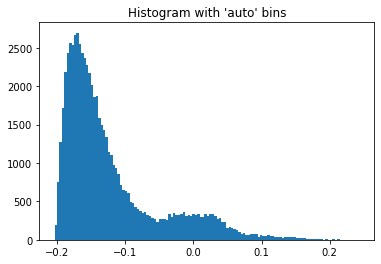

```python
plt.hist(y_test_scores, bins='auto')  # arguments are passed to np.histogram
plt.title("Histogram with 'auto' bins")
plt.show()
```

## Discussion:

It is a bit difficult to see the number of outliers here. It is less apparent in this histogram. Compared to the Autoencoder model, the IForest model anomaly scores have very low variance. As a result, I chose 0.1, because it is far away from the bimodal chart, and I think the points on the right side of 0.1 do represent the anomalies here.

```python
X_test_cluster = X_test1.copy()
X_test_cluster.reset_index(inplace=True)
X_test_cluster['distance'] = y_test_scores
X_test_cluster['cluster'] = np.where(X_test_cluster['distance']< 0.1, 0, 1)
X_test_cluster['cluster'].value_counts()
```

```
0    64438
1      788
Name: cluster, dtype: int64
```

```python
summary4 = X_test_cluster.groupby('cluster').mean()
summary4.insert(0,column='count',
                value=X_test_cluster['cluster'].value_counts())
summary4.drop(columns='index', inplace=True)
summary4
```

| cluster | count | Average Copay | Total Payments | Medicare Coverage | Medicare Coverage Ratio | Average TP Anomaly | Average TP Ratio | Average TD Anomaly | Average TD Ratio | Average Covered Charges Anomaly | Average Covered Charges Ratio | distance |
| --- | --- | --- | --- | --- | --- | --- | --- | --- | --- | --- | --- | --- |
| 0 | 64438 | 1197.002582 | 402991.976616 | 0.846969 | 0.846321 | 0.039247 | 0.982934 | 0.048263 | 0.993435 | 0.034203 | 0.987950 | -0.124933 |
| 1 | 788 | 2616.950305 | 917329.560228 | 0.816304 | 0.865616 | 0.705584 | 1.518854 | 0.289340 | 1.579144 | 0.800761 | 1.957286 | 0.134380 |

## Discussion:

Although the number of observations in Cluster 1 here are greater because there was no apparent cutoff point in the histogram chart. The differences in each feature is still significant. For example, Cluster 1's Average Copay and Total Payments are 2 times higher than Cluster 0. All the anomaly indicative features are higher in Cluster 1 than those in Cluster 0. Lastly, the anomaly scores are different, one is positive and the other one is negative.

## Model 2

```python
clf2 = IForest(behaviour="new", max_samples=80)
clf2.fit(X_train)
```

```
IForest(behaviour='new', bootstrap=False, contamination=0.1, max_features=1.0,
    max_samples=80, n_estimators=100, n_jobs=1, random_state=None,
    verbose=0)
```

```python
# clf.decision_function: Predict raw anomaly score of X using the fitted detector.
y_test_scores = clf2.decision_function(X_test)  # outlier scores
y_test_scores = pd.Series(y_test_scores)
y_test_scores.head()
```

```
0    0.059022
1   -0.182615
2   -0.096738
3   -0.165725
4   -0.013247
dtype: float64
```

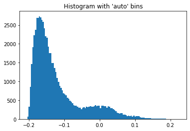

```python
plt.hist(y_test_scores, bins='auto')  # arguments are passed to np.histogram
plt.title("Histogram with 'auto' bins")
plt.show()
```

## Discussion:

This chart is similar to the model one. There was not a huge difference.

```python
X_test_cluster = X_test1.copy()
X_test_cluster.reset_index(inplace=True)
X_test_cluster['distance'] = y_test_scores
X_test_cluster['cluster'] = np.where(X_test_cluster['distance']< 0.1, 0, 1)
X_test_cluster['cluster'].value_counts()
```

```
0    64565
1      661
Name: cluster, dtype: int64
```

```python
summary5 = X_test_cluster.groupby('cluster').mean()
summary5.insert(0,column='count',
                value=X_test_cluster['cluster'].value_counts())
summary5.drop(columns='index', inplace=True)
summary5
```

| cluster | count | Average Copay | Total Payments | Medicare Coverage | Medicare Coverage Ratio | Average TP Anomaly | Average TP Ratio | Average TD Anomaly | Average TD Ratio | Average Covered Charges Anomaly | Average Covered Charges Ratio | distance |
| --- | --- | --- | --- | --- | --- | --- | --- | --- | --- | --- | --- | --- |
| 0 | 64565 | 1197.664152 | 4.024740e+05 | 0.847020 | 0.846348 | 0.041447 | 0.984357 | 0.046109 | 0.988046 | 0.037683 | 0.991366 | -0.122482 |
| 1 | 661 | 2825.148684 | 1.066741e+06 | 0.805482 | 0.866644 | 0.618759 | 1.482814 | 0.546142 | 2.218157 | 0.608169 | 1.809934 | 0.125304 |

## Discussion:

# Model 3

```python
clf3 = IForest(behaviour="new", max_samples=60)
clf3.fit(X_train)
```

```
IForest(behaviour='new', bootstrap=False, contamination=0.1, max_features=1.0,
    max_samples=60, n_estimators=100, n_jobs=1, random_state=None,
    verbose=0)
```

```python
# clf.decision_function: Predict raw anomaly score of X using the fitted detector.
y_test_scores = clf3.decision_function(X_test)  # outlier scores
y_test_scores = pd.Series(y_test_scores)
y_test_scores.head()
```

```
0    0.025813
1   -0.166648
2   -0.098782
3   -0.156767
4    0.041177
dtype: float64
```

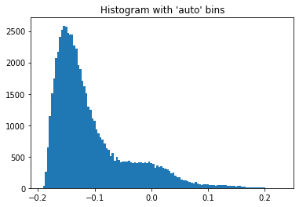

```python
plt.hist(y_test_scores, bins='auto')  # arguments are passed to np.histogram
plt.title("Histogram with 'auto' bins")
plt.show()
```

## Discussion:

I continue to choose 0.1 as the cutoff point because I want to see how will the summary statistics differed for the three models.

```python
X_test_cluster = X_test1.copy()
X_test_cluster.reset_index(inplace=True)
X_test_cluster['distance'] = y_test_scores
X_test_cluster['cluster'] = np.where(X_test_cluster['distance']< 0.1, 0, 1)
X_test_cluster['cluster'].value_counts()
```

```
0    64451
1      775
Name: cluster, dtype: int64
```

```python
summary6 = X_test_cluster.groupby('cluster').mean()
summary6.insert(0,column='count',
                value=X_test_cluster['cluster'].value_counts())
summary6.drop(columns='index', inplace=True)
summary6
```

| cluster | count | Average Copay | Total Payments | Medicare Coverage | Medicare Coverage Ratio | Average TP Anomaly | Average TP Ratio | Average TD Anomaly | Average TD Ratio | Average Covered Charges Anomaly | Average Covered Charges Ratio | distance |
| --- | --- | --- | --- | --- | --- | --- | --- | --- | --- | --- | --- | --- |
| 0 | 64451 | 1199.771183 | 402402.939244 | 0.846773 | 0.846281 | 0.038587 | 0.982735 | 0.049200 | 0.995580 | 0.033964 | 0.987748 | -0.109663 |
| 1 | 775 | 2410.524839 | 974943.026400 | 0.832077 | 0.869244 | 0.771613 | 1.544395 | 0.215484 | 1.410663 | 0.833548 | 1.990360 | 0.135041 |

## Aggregated Models

```python
from pyod.utils.utility import standardizer
from pyod.utils.data import evaluate_print
```

```python
# The predictions of the training data can be obtained by clf.decision_scores_.
# It is already generated during the model building process.
train_scores = pd.DataFrame({'clf1': clf1.decision_scores_,
                             'clf2': clf2.decision_scores_,
                             'clf3': clf3.decision_scores_
                            })

# The predictions of the test data need to be predicted using clf.decision_function(X_test)
test_scores  = pd.DataFrame({'clf1': clf1.decision_function(X_test),
                             'clf2': clf2.decision_function(X_test),
                             'clf3': clf3.decision_function(X_test)
                            })
```

```python
train_scores.head()
```

|  | clf1 | clf2 | clf3 |
| --- | --- | --- | --- |
| 0 | -0.172982 | -0.169208 | -0.154549 |
| 1 | -0.138944 | -0.138207 | -0.115247 |
| 2 | 0.162654 | 0.106778 | 0.131619 |
| 3 | -0.108307 | -0.120290 | -0.090371 |
| 4 | -0.124696 | -0.121742 | -0.095974 |

```python
test_scores.head()
```

|  | clf1 | clf2 | clf3 |
| --- | --- | --- | --- |
| 0 | 0.060995 | 0.059022 | 0.025813 |
| 1 | -0.177107 | -0.182615 | -0.166648 |
| 2 | -0.110354 | -0.096738 | -0.098782 |
| 3 | -0.168699 | -0.165725 | -0.156767 |
| 4 | 0.045120 | -0.013247 | 0.041177 |

```python
# Although we did standardization before, it was for the variables.
# Now we do the standardization for the decision scores
train_scores_norm, test_scores_norm = standardizer(train_scores,test_scores)
```

```python
train_scores_norm.shape
```

```
(97839, 3)
```

## Average of the Average

```python
# Combination by average of each row
y_by_average = average(test_scores_norm)
y_by_average[1:10]
```

```
array([-0.8562013 ,  0.18880328, -0.68956038,  1.98808544, -0.67274777,
        0.3624149 , -0.95411565,  2.0141919 , -0.55113157])
```

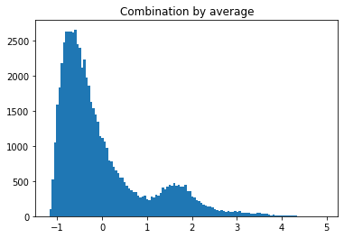

```python
plt.hist(y_by_average, bins='auto')  # arguments are passed to np.histogram
plt.title("Combination by average")
plt.show()
```

## Discussion:

```python
df_test = pd.DataFrame(X_test1)
df_test.reset_index(inplace=True)
df_test['y_by_average_score'] = y_by_average
df_test['y_by_average_cluster'] = np.where(df_test['y_by_average_score']<3, 0, 1)
df_test['y_by_average_cluster'].value_counts()
```

```
0    64443
1      783
Name: y_by_average_cluster, dtype: int64
```

```python
summaryagg3 = df_test.groupby('y_by_average_cluster').mean()
summaryagg3.insert(0,column='count',
                value=df_test['y_by_average_cluster'].value_counts())
summaryagg3.drop(columns='index', inplace=True)
summaryagg3
```

| y_by_average_cluster | count | Average Copay | Total Payments | Medicare Coverage | Medicare Coverage Ratio | Average TP Anomaly | Average TP Ratio | Average TD Anomaly | Average TD Ratio | Average Covered Charges Anomaly | Average Covered Charges Ratio | y_by_average_score |
| --- | --- | --- | --- | --- | --- | --- | --- | --- | --- | --- | --- | --- |
| 0 | 64443 | 1197.022869 | 402329.644217 | 0.846910 | 0.846308 | 0.038996 | 0.982803 | 0.047996 | 0.992715 | 0.034589 | 0.988085 | -0.053978 |
| 1 | 783 | 2624.348046 | 975125.696552 | 0.820959 | 0.866799 | 0.730524 | 1.533046 | 0.312899 | 1.642148 | 0.773946 | 1.952377 | 3.450392 |

## Discussion:

# Maximum of maximum

```python
# Combination by max
y_by_maximization = maximization(test_scores_norm)
y_by_maximization
```

```
array([ 2.50559151, -0.76832393,  0.31203376, ..., -0.5393209 ,
       -0.4976316 ,  1.70416365])
```

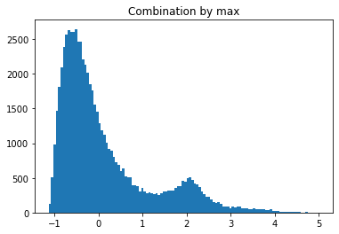

```python
# plotting
plt.hist(y_by_maximization, bins='auto')  # arguments are passed to np.histogram
plt.title("Combination by max")
plt.show()
```

```python
df_test = pd.DataFrame(X_test1)
df_test['y_by_maximization_score'] = y_by_maximization
df_test['y_by_maximization_cluster'] = np.where(
    df_test['y_by_maximization_score']<3, 0, 1)
df_test['y_by_maximization_cluster'].value_counts()
```

```
0    64088
1     1138
Name: y_by_maximization_cluster, dtype: int64
```

```python
summaryagg4 = df_test.groupby('y_by_maximization_cluster').mean()
summaryagg4.insert(0,column='count',
                value=df_test['y_by_maximization_cluster'].value_counts())
summaryagg4.drop(columns='index', inplace=True)
summaryagg4
```

| y_by_maximization_cluster | count | Average Copay | Total Payments | Medicare Coverage | Medicare Coverage Ratio | Average TP Anomaly | Average TP Ratio | Average TD Anomaly | Average TD Ratio | Average Covered Charges Anomaly | Average Covered Charges Ratio | y_by_average_score | y_by_average_cluster | y_by_maximization_score |
| --- | --- | --- | --- | --- | --- | --- | --- | --- | --- | --- | --- | --- | --- | --- |
| 0 | 64088 | 1191.097786 | 399192.952724 | 0.847207 | 0.846276 | 0.036902 | 0.981433 | 0.045703 | 0.987285 | 0.032253 | 0.985196 | -0.069983 | 0.000000 | 0.063256 |
| 1 | 1138 | 2512.771828 | 973088.513620 | 0.812329 | 0.862202 | 0.632689 | 1.438555 | 0.359402 | 1.745403 | 0.674868 | 1.814268 | 3.258585 | 0.688049 | 3.513212 |

## Discussion:

Although I use the same strategy to pick the cutoff point, the results are significantly different in terms of the number of observations in each cluster. It does, however, makes sense. Becaues this aggregation strategy takes the maximum anomaly score and aggregate them. As such, the number of observations in Cluster 1 is higher. and the range of the distance is also higher than the "average of the average" aggregation method.

```python
# end...
```